# iris

## O Danych

Zbiór danych zawiera informacje o trzech gatunkach irysów: Iris setosa, Iris versicolor, i Iris virginica.

Dane obejmują pomiary czterech cech: długość i szerokość działki kielicha oraz długość i szerokość płatka.

Każdy wiersz w zbiorze danych reprezentuje pojedynczy kwiat, a wartości pomiarów są podane w centymetrach.

Zbiór składa się z 150 próbek, po 50 dla każdego gatunku, i jest szeroko stosowany jako podstawowy zbiór danych do testowania algorytmów klasyfikacji oraz w nauce o danych i uczeniu maszynowym.

Kolumny:

- **długość kielicha (sepal length)** - Długość kielicha w cm
- **szerokość kielicha (sepal width)** - Szerokość kielicha w cm
- **długość płatka (petal length)** - Długość płatka w cm
- **szerokość płatka (petal width)** - Szerokość płatka w cm
- **klasa (class)** - Klasa irysa (setosa, versicolor, virginica)

```python
import pandas as pd
import matplotlib.pyplot as plt
```

```python
df = pd.read_csv('25__iris.csv', sep=",")
df
```

|  | długość kielicha (sepal length) | szerokość kielicha (sepal width) | długość płatka (petal length) | szerokość płatka (petal width) | klasa (class) |
| --- | --- | --- | --- | --- | --- |
| 0 | 5.1 | 3.5 | 1.4 | 0.2 | Iris-setosa |
| 1 | 4.9 | 3.0 | 1.4 | 0.2 | Iris-setosa |
| 2 | 4.7 | 3.2 | 1.3 | 0.2 | Iris-setosa |
| 3 | 4.6 | 3.1 | 1.5 | 0.2 | Iris-setosa |
| 4 | 5.0 | 3.6 | 1.4 | 0.2 | Iris-setosa |
| ... | ... | ... | ... | ... | ... |
| 145 | 6.7 | 3.0 | 5.2 | 2.3 | Iris-virginica |
| 146 | 6.3 | 2.5 | 5.0 | 1.9 | Iris-virginica |
| 147 | 6.5 | 3.0 | 5.2 | 2.0 | Iris-virginica |
| 148 | 6.2 | 3.4 | 5.4 | 2.3 | Iris-virginica |
| 149 | 5.9 | 3.0 | 5.1 | 1.8 | Iris-virginica |

150 rows × 5 columns

# Wykonujemy analizę w odpowiedniość do EDA

### 1. Ogólny przegląd danych

```python
# Wybieramy 10 randomowych wierszy z dataframe
random_rows = df.sample(n=10)
random_rows
```

|  | długość kielicha (sepal length) | szerokość kielicha (sepal width) | długość płatka (petal length) | szerokość płatka (petal width) | klasa (class) |
| --- | --- | --- | --- | --- | --- |
| 58 | 6.6 | 2.9 | 4.6 | 1.3 | Iris-versicolor |
| 113 | 5.7 | 2.5 | 5.0 | 2.0 | Iris-virginica |
| 44 | 5.1 | 3.8 | 1.9 | 0.4 | Iris-setosa |
| 95 | 5.7 | 3.0 | 4.2 | 1.2 | Iris-versicolor |
| 104 | 6.5 | 3.0 | 5.8 | 2.2 | Iris-virginica |
| 149 | 5.9 | 3.0 | 5.1 | 1.8 | Iris-virginica |
| 37 | 4.9 | 3.1 | 1.5 | 0.1 | Iris-setosa |
| 141 | 6.9 | 3.1 | 5.1 | 2.3 | Iris-virginica |
| 25 | 5.0 | 3.0 | 1.6 | 0.2 | Iris-setosa |
| 112 | 6.8 | 3.0 | 5.5 | 2.1 | Iris-virginica |

*Dane nie zawierają podejrzanych wartości. Zwracamy uwagę na to że jedna kolumna ma identyfikator klasy kwiatu, co jest kluczem do zbioru danych po rodzaju*

```python
# Upewniamy się że wierszy 150
row_count = len(df)
print(f"Ilość wierszy = {row_count}")

# Sprawdzamy dane na unikalne wartości
unique_values_per_column = df.nunique()
unique_values_per_column
```

```
Ilość wierszy = 150
```

```
długość kielicha (sepal length)     35
szerokość kielicha (sepal width)    23
długość płatka (petal length)       43
szerokość płatka (petal width)      22
klasa (class)                        3
dtype: int64
```

```python
# Wykonujemy podsumowanie dla numerycznych kolumn
summary_stats = df.describe()
summary_stats
```

|  | długość kielicha (sepal length) | szerokość kielicha (sepal width) | długość płatka (petal length) | szerokość płatka (petal width) |
| --- | --- | --- | --- | --- |
| count | 150.000000 | 150.000000 | 150.000000 | 150.000000 |
| mean | 5.843333 | 3.054000 | 3.758667 | 1.198667 |
| std | 0.828066 | 0.433594 | 1.764420 | 0.763161 |
| min | 4.300000 | 2.000000 | 1.000000 | 0.100000 |
| 25% | 5.100000 | 2.800000 | 1.600000 | 0.300000 |
| 50% | 5.800000 | 3.000000 | 4.350000 | 1.300000 |
| 75% | 6.400000 | 3.300000 | 5.100000 | 1.800000 |
| max | 7.900000 | 4.400000 | 6.900000 | 2.500000 |

### 2. Analiza brakujących wartości

```python
# Sprawdzamy czy są puste komórki
print('First way to check if there are empty cells:')
print()
df.info()
print()
print('Second way to check if there are empty cells:')
print()
df.isnull().sum()
```

```
First way to check if there are empty cells:

<class 'pandas.core.frame.DataFrame'>
RangeIndex: 150 entries, 0 to 149
Data columns (total 5 columns):
 #   Column                            Non-Null Count  Dtype
---  ------                            --------------  -----
 0   długość kielicha (sepal length)   150 non-null    float64
 1   szerokość kielicha (sepal width)  150 non-null    float64
 2   długość płatka (petal length)     150 non-null    float64
 3   szerokość płatka (petal width)    150 non-null    float64
 4   klasa (class)                     150 non-null    object
dtypes: float64(4), object(1)
memory usage: 6.0+ KB

Second way to check if there are empty cells:
```

```
długość kielicha (sepal length)     0
szerokość kielicha (sepal width)    0
długość płatka (petal length)       0
szerokość płatka (petal width)      0
klasa (class)                       0
dtype: int64
```

*Widzimy że dane nie mają pustych wartości.*

### 3. Analiza pojedynczych zmiennych

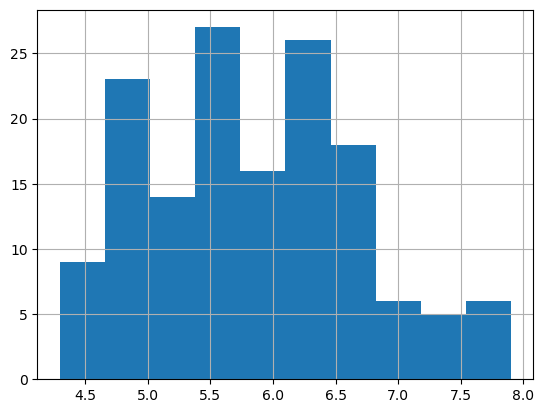

```python
# Wizualizujemy dane za pomocą histogramów
df['długość kielicha (sepal length)'].hist()
```

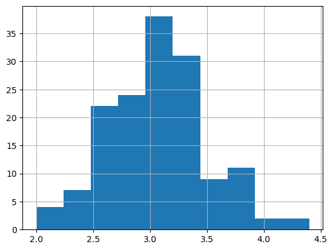

```python
df['szerokość kielicha (sepal width)'].hist()
```

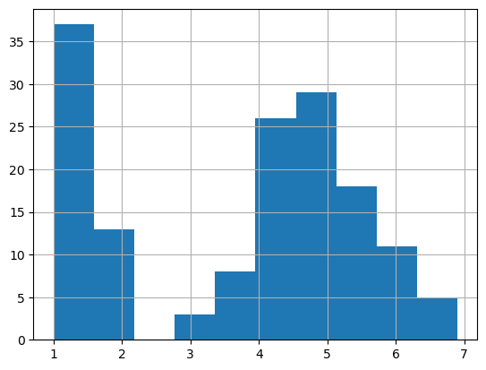

```python
df['długość płatka (petal length)'].hist()
```

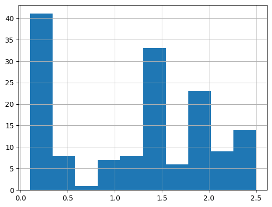

```python
df['szerokość płatka (petal width)'].hist()
```

*Histogramy pokazują że w zbiorze danych najwięcej kwiatów z długością kielicha na około 5,6 / 6,3 cm, szerokością kielicha 3,1 cm, długością płatka 1,2 cm i szerokością płatka 0,2 cm*

```python
# Wykonujemy podsumowanie dla numerycznych kolumn dla każdego gatunku
agg_df = df.groupby('klasa (class)', as_index=False).agg({'długość kielicha (sepal length)': ['count', 'mean', 'std', 'min', lambda x: x.quantile(.25), 'median', lambda x: x.quantile(.75), 'max']})
agg_df
```

|  | klasa (class) | długość kielicha (sepal length) count | długość kielicha (sepal length) mean | długość kielicha (sepal length) std | długość kielicha (sepal length) min | długość kielicha (sepal length) <lambda_0> | długość kielicha (sepal length) median | długość kielicha (sepal length) <lambda_1> | długość kielicha (sepal length) max |
| --- | --- | --- | --- | --- | --- | --- | --- | --- | --- |
| 0 | Iris-setosa | 50 | 5.006 | 0.352490 | 4.3 | 4.800 | 5.0 | 5.2 | 5.8 |
| 1 | Iris-versicolor | 50 | 5.936 | 0.516171 | 4.9 | 5.600 | 5.9 | 6.3 | 7.0 |
| 2 | Iris-virginica | 50 | 6.588 | 0.635880 | 4.9 | 6.225 | 6.5 | 6.9 | 7.9 |

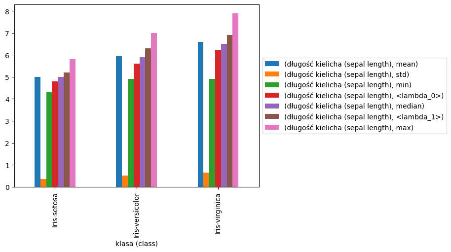

```python
# Wizualizacja danych
# Wyrzucamy kolumnę count
agg_df = agg_df.drop(('długość kielicha (sepal length)', 'count'), axis=1)
agg_df.plot(kind='bar', x='klasa (class)')
# Przesuwamy legendę poza wykres
plt.legend(loc='center left', bbox_to_anchor=(1.0, 0.5))
plt.show()
```

```python
agg_df = df.groupby('klasa (class)', as_index=False).agg({'szerokość kielicha (sepal width)': ['count', 'mean', 'std', 'min', lambda x: x.quantile(.25), 'median', lambda x: x.quantile(.75), 'max']})
agg_df
```

|  | klasa (class) | szerokość kielicha (sepal width) count | szerokość kielicha (sepal width) mean | szerokość kielicha (sepal width) std | szerokość kielicha (sepal width) min | szerokość kielicha (sepal width) <lambda_0> | szerokość kielicha (sepal width) median | szerokość kielicha (sepal width) <lambda_1> | szerokość kielicha (sepal width) max |
| --- | --- | --- | --- | --- | --- | --- | --- | --- | --- |
| 0 | Iris-setosa | 50 | 3.418 | 0.381024 | 2.3 | 3.125 | 3.4 | 3.675 | 4.4 |
| 1 | Iris-versicolor | 50 | 2.770 | 0.313798 | 2.0 | 2.525 | 2.8 | 3.000 | 3.4 |
| 2 | Iris-virginica | 50 | 2.974 | 0.322497 | 2.2 | 2.800 | 3.0 | 3.175 | 3.8 |

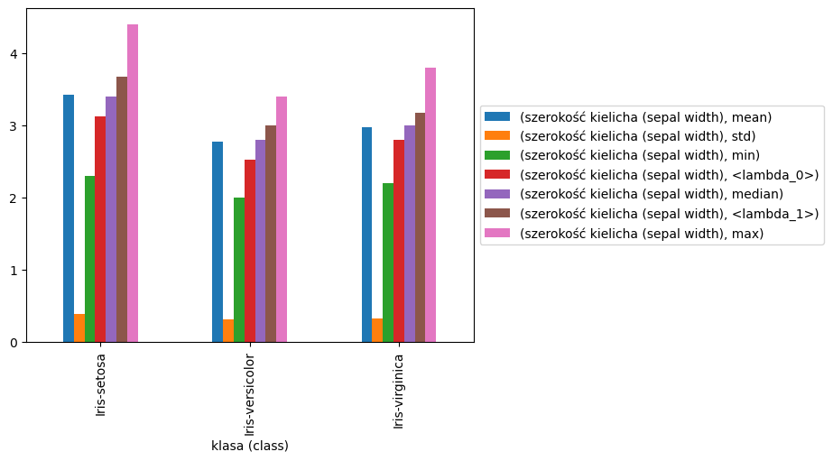

```python
agg_df = agg_df.drop(('szerokość kielicha (sepal width)', 'count'), axis=1)
agg_df.plot(kind='bar', x='klasa (class)')
plt.legend(loc='center left', bbox_to_anchor=(1.0, 0.5))
plt.show()
```

```python
agg_df = df.groupby('klasa (class)', as_index=False).agg({'długość płatka (petal length)': ['count', 'mean', 'std', 'min', lambda x: x.quantile(.25), 'median', lambda x: x.quantile(.75), 'max']})
agg_df
```

|  | klasa (class) | długość płatka (petal length) count | długość płatka (petal length) mean | długość płatka (petal length) std | długość płatka (petal length) min | długość płatka (petal length) <lambda_0> | długość płatka (petal length) median | długość płatka (petal length) <lambda_1> | długość płatka (petal length) max |
| --- | --- | --- | --- | --- | --- | --- | --- | --- | --- |
| 0 | Iris-setosa | 50 | 1.464 | 0.173511 | 1.0 | 1.4 | 1.50 | 1.575 | 1.9 |
| 1 | Iris-versicolor | 50 | 4.260 | 0.469911 | 3.0 | 4.0 | 4.35 | 4.600 | 5.1 |
| 2 | Iris-virginica | 50 | 5.552 | 0.551895 | 4.5 | 5.1 | 5.55 | 5.875 | 6.9 |

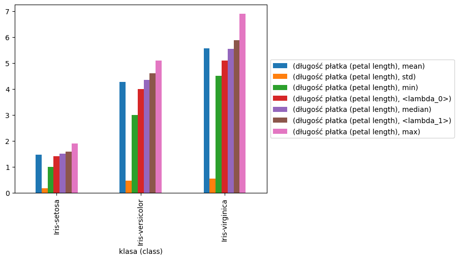

```python
agg_df = agg_df.drop(('długość płatka (petal length)', 'count'), axis=1)
agg_df.plot(kind='bar', x='klasa (class)')
plt.legend(loc='center left', bbox_to_anchor=(1.0, 0.5))
plt.show()
```

```python
agg_df = df.groupby('klasa (class)', as_index=False).agg({'szerokość płatka (petal width)': ['count', 'mean', 'std', 'min', lambda x: x.quantile(.25), 'median', lambda x: x.quantile(.75), 'max']})
agg_df
```

|  | klasa (class) | szerokość płatka (petal width) count | szerokość płatka (petal width) mean | szerokość płatka (petal width) std | szerokość płatka (petal width) min | szerokość płatka (petal width) <lambda_0> | szerokość płatka (petal width) median | szerokość płatka (petal width) <lambda_1> | szerokość płatka (petal width) max |
| --- | --- | --- | --- | --- | --- | --- | --- | --- | --- |
| 0 | Iris-setosa | 50 | 0.244 | 0.107210 | 0.1 | 0.2 | 0.2 | 0.3 | 0.6 |
| 1 | Iris-versicolor | 50 | 1.326 | 0.197753 | 1.0 | 1.2 | 1.3 | 1.5 | 1.8 |
| 2 | Iris-virginica | 50 | 2.026 | 0.274650 | 1.4 | 1.8 | 2.0 | 2.3 | 2.5 |

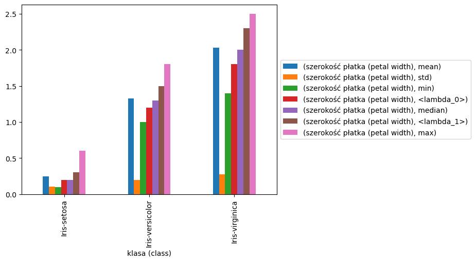

```python
agg_df = agg_df.drop(('szerokość płatka (petal width)', 'count'), axis=1)
agg_df.plot(kind='bar', x='klasa (class)')
plt.legend(loc='center left', bbox_to_anchor=(1.0, 0.5))
plt.show()
```

*Widzimy że podsumowanie numerycznych kolumn bardzo podobne u kielichów, ale płatki iris-setosa mają mniejsze wartości u porówniani z inymi rodzajami irysów*

### 4. Transformacja danych

*W tym przypadku transformacja nie jest potrzebna, nie mamy brakujących wartości*

### 5. Analiza relacji między zmiennymi

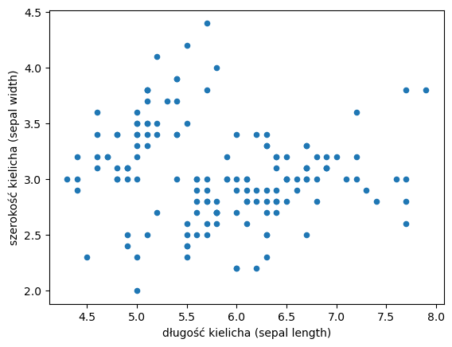

```python
# Zobaczmy jak się zmiwnia szyrokość w raz z długościu dla kielicha i płatka
df.plot(kind='scatter', x = 'długość kielicha (sepal length)', y = 'szerokość kielicha (sepal width)')
```

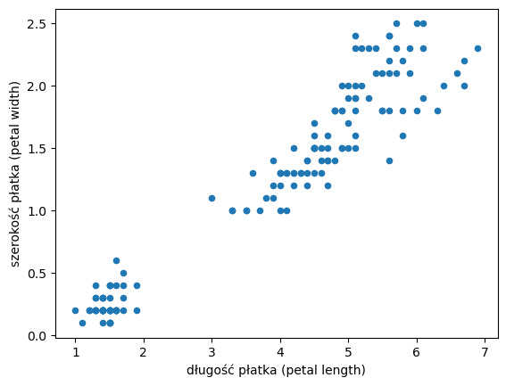

```python
df.plot(kind='scatter', x = 'długość płatka (petal length)', y = 'szerokość płatka (petal width)')
```

```python
# Macierz korelacji
correlation_matrix = df.corr()
correlation_matrix
```

|  | długość kielicha (sepal length) | szerokość kielicha (sepal width) | długość płatka (petal length) | szerokość płatka (petal width) |
| --- | --- | --- | --- | --- |
| długość kielicha (sepal length) | 1.000000 | -0.109369 | 0.871754 | 0.817954 |
| szerokość kielicha (sepal width) | -0.109369 | 1.000000 | -0.420516 | -0.356544 |
| długość płatka (petal length) | 0.871754 | -0.420516 | 1.000000 | 0.962757 |
| szerokość płatka (petal width) | 0.817954 | -0.356544 | 0.962757 | 1.000000 |

### 6. Analiza wartości odstających

[output not shown]

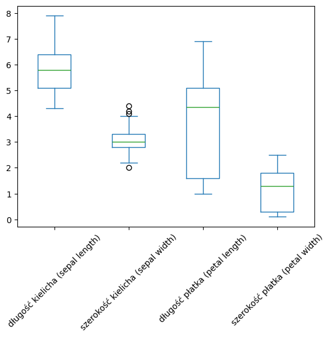

```python
df.plot(kind='box')
plt.xticks(rotation=45)
```

*Analiza pokazuję, że odstające wartości ma szerokość kielicha*

## Podsumuwanie analizy

*Analizując dane trzech gatunków irysów dochodzimy do wniosków:*

1. Długość i szerokość kielichów niewiele się różnią między sobą, chociaż irys-virginica ma nieco większą długość, jednak szurokość niznacznie większa dla iris-setosa.
2. Długość i szerokość płatków nieco większa dla irisa-virginica od irisa-versicolor, ale znacznie mniejsze wartości długości i szyrokości dla płatków mają iris-setosa od irisa-virginica i irisa-versicolor
3. Szerokość i długość płatków znajdują się między sobą w relacji blizką do wprost proporcjonalnej (korelacja dodatnia i wynosi prawie jedynkę). Widzimy to równiesz jasne na scatter-plotie.
4. Szerokość i długość kielichów prawie nie korelują między sobą, natomiast długość kielicha ma dodatnie korelacje między długościu i szerokościu płatka, a szerokość kielicha ma ujemne korelacje między długością i szerokością płatka.
5. Zbiór danych odnośnie irysów prawie nie zawierał wartości odstających, chociaż nieco mamy trochę tych wartości dla szerokości kielicha.